# ResNet50 CNN model

In this assignment, I used transfer learning on a pre-trained ResNet50 CNN model trained on the ImageNet dataset to perform classification for recognizing images of horses and camels using the dataset horses_and_camels.zip (https://www.kaggle.com/akrsnv/horses-and-camels),upload it to my OneDrive(https://uofh-my.sharepoint.com/:u:/g/personal/whuang31_cougarnet_uh_edu/EcUe5GkxayVHsydmMWabbYUBu7iXBw2cUxjkPjZUzEnEOQ?download=1 -O horses_and_camels.zip).

First, import dataset. Download the dataset horses_and_camels.zip to local dir and extract it. Create a train_dataset for training and a test_dataset by using the keras.utils.image_dataset_from_directory utility.

Then, preprocessing, such as configure the dataset for performance, Use data augmentation, and rescale pixel values.

Next, created the fine_tuning training model based on the pre-models,plot the training learning curve (loss-epochs) and discussed if the model is overfitted, under-fitted, or well-trained.

Last, testing and evalution, showed the confusion matrix;calculated the accurary, precision, sensitivity and specificity; plot the ROC of the trained model.

```python
import matplotlib.pyplot as plt
import numpy as np
import os
import tensorflow as tf
from tensorflow import keras
import sklearn
from sklearn.metrics import confusion_matrix,roc_curve,auc
import itertools
```

[output not shown]

Import dataset

Download the dataset horses_and_camels.zip to local dir and extract it. Create a train_dataset for training and a test_dataset by using the keras.utils.image_dataset_from_directory utility.

```python
#import the local dataset archive.zip, which includes the images of horses and camels for training and testing.
local_file = os.path.abspath('./horses_and_camels.zip')
path_to_zip = tf.keras.utils.get_file(local_file,'file://'+local_file)
PATH = os.path.join(os.path.dirname(path_to_zip), 'horses_and_camels')
train_dir = os.path.join(PATH, 'train')
test_dir = os.path.join(PATH, 'test')
BATCH_SIZE = 32
IMG_SIZE = (160, 160)
#creat a train_dataset for training by using the keras.utils.image_dataset_from_directory utility.
train_dataset = keras.utils.image_dataset_from_directory(train_dir,
                                                            shuffle=True,
                                                            batch_size=BATCH_SIZE,
                                                            image_size=IMG_SIZE)
```

```
Found 360 files belonging to 2 classes.
```

[output not shown]

```python
#creat a test_dataset for testing by using the keras.utils.image_dataset_from_directory utility.
test_dataset = keras.utils.image_dataset_from_directory(test_dir,
                                                                 shuffle=True,
                                                                 batch_size=BATCH_SIZE,
                                                                 image_size=IMG_SIZE)
```

```
Found 40 files belonging to 2 classes.
```

Show the first nine images and labels from the training set.

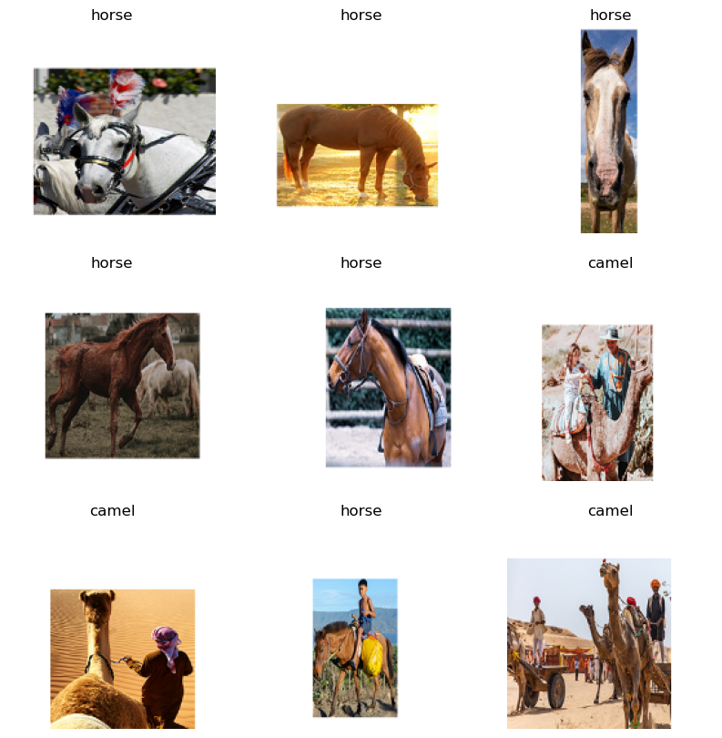

```python
class_names = train_dataset.class_names
#Show the first nine images and labels from the training set (train_dataset)
plt.figure(figsize=(10, 10))
for images, labels in train_dataset.take(1):
  for i in range(9):
    ax = plt.subplot(3, 3, i + 1)
    plt.imshow(images[i].numpy().astype("uint8"))
    plt.title(class_names[labels[i]])
    plt.axis("off")
```

Configure the dataset for performance

Use buffered prefetching to load images from disk without having I/O become blocking.

```python
AUTOTUNE = tf.data.AUTOTUNE
#using buffered prefetching to load images from disk
train_dataset = train_dataset.prefetch(buffer_size=AUTOTUNE)
test_dataset = test_dataset.prefetch(buffer_size=AUTOTUNE)
```

Use data augmentation

When we don't have a large image dataset, it's a good practice to artificially introduce sample diversity by applying random, yet realistic, transformations to the training images, such as rotation and horizontal flipping. This helps expose the model to different aspects of the training data and reduce overfitting.

```python
#use data augmentation,such as rotation and horizontal flipping, transformations to the training images.
data_augmentation = keras.Sequential([
  keras.layers.RandomFlip('horizontal'),
  keras.layers.RandomRotation(0.2),
])
```

Repeatedly apply these layers to the same image and see the result.

[output not shown]

[output cut: 18 more lines]

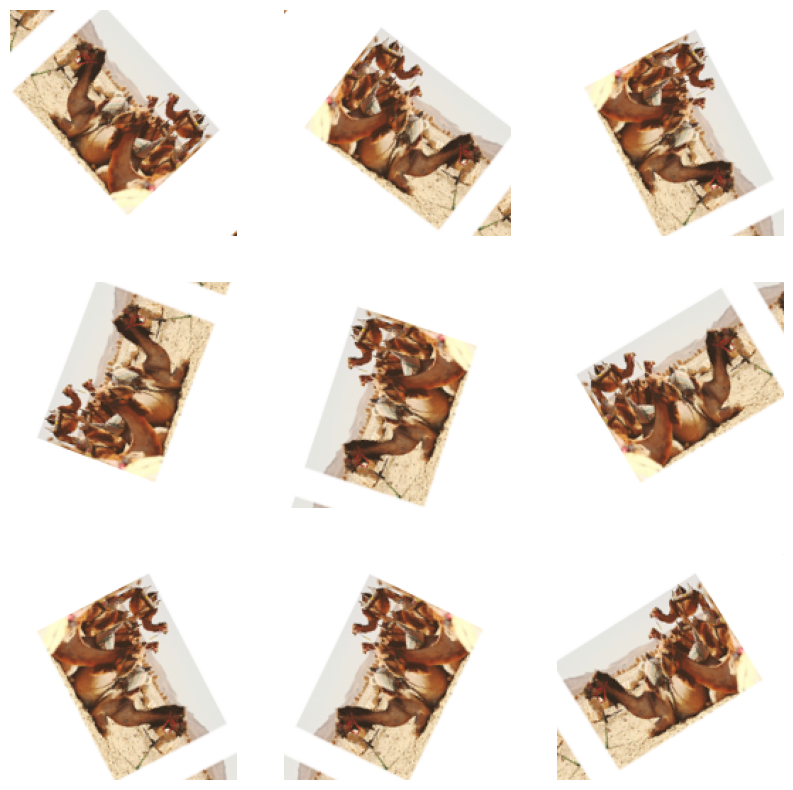

```python
#repeatedly apply these layers to the same image and show the result.
for image, _ in train_dataset.take(1):
  plt.figure(figsize=(10, 10))
  first_image = image[0]
  for i in range(9):
    ax = plt.subplot(3, 3, i + 1)
    augmented_image = data_augmentation(tf.expand_dims(first_image, 0))
    plt.imshow(augmented_image[0] / 255)
    plt.axis('off')
```

Rescale pixel values

```python
#Using keras.applications.keras.ResNet50 as the base model
preprocess_input = keras.applications.resnet50.preprocess_input
#Rescale pixel values from [0, 255] to [-1, 1]
rescale = keras.layers.Rescaling(1./127.5, offset=-1)
```

Create the base model from the pre-trained convnets